# Análise da População Adulta do Noroeste Fluminense a partir do R

### Gabriel Dias de Carvalho Alves Pereira, Larissa Ribeiro de Jesus, Mariana Pinheiro Costa Pimentel

### 2017-10-16

```r
> PopulaçãoFluminense <-
+   readXL("C:/Users/Mariana/SkyDrive/Faculdade/BIOESTATISTICA/adultos_do_Noroeste Fluminense.xlsx",
+   rownames=FALSE, header=TRUE, na="", sheet="banco", stringsAsFactors=TRUE)
```

[output not shown]

```
INTRODUÇÃO:
O noroeste fluminense é composto por Aperibé, Bom Jesus do Itabapoana, Cambuci, Italva, Itaocara, Itaperuna, Laje do Muriaé, Miracema, Natividade, Porciúncula, Santo Antônio de Pádua, São José de Ubá e Varre-Sai, somando ao todo treze municípios.
O desbravamento da região começou na época da colonização portuguesa para o plantio de cana de açúcar, que posteriormente foi substituída pela lavoura de café no século XIX, predominando na região até meados dos anos 30.
Atualmente a localidade possui uma economia diversificada, contando com a fruticultura, a criação de gado e a produção leiteira, a agro-indústria sucroalcooleira, e as indústrias de doces, aguardente, produção de arroz, calcário, cimento e pedras em geral.
Em relação a população, o Noroeste Fluminense possui 324.013 habitantes de acordo com os dados do IBGE de 2015. Sendo assim, é necessária uma avaliação do perfil populacional dessa região para melhor diagnóstico e elaboração de políticas públicas.
```

```
OBJETIVO:
Realizar a análise do perfil populacional do Noroeste Fluminense segundo os dados descritos na base "População Adulta do Noroeste Fluminense".
Baseado nisso, fazer o diagnóstico da população, pontos positivos e negativos, a fim de elaborar políticas públicas ao ministro de saúde.
```

```
METODOLOGIA:
A pesquisa foi realizada através das informações obtidas no censo preparado pelo setor de pesquisa aplicada, no qual foram entrevistados 32.561 adultos do noroeste fluminense.
A coleta de dados abrange a idade, ocupação, salário em 12 meses, escolaridade, anos de estudo, situação conjugal, setor, raça, sexo, horas de trabalho na semana e local.
Foi estabelecida uma relação entre as variáveis através de gráficos executados com o software R. Sendo aplicadas funções do software, como: Gráfico de pizza, gráfico de barras, histograma, boxplot, diagrama de dispersão, matriz de correlação.
```

```
RESULTADOS E DISCUSSÃO
```

```
DISTRIBUIÇÃO DE FREQUÊNCIA:
O teste foi realizado a fim de obter um panorâma mais completo, permitindo traçar um diagnóstico condizente a essa população.
```

````
Escolaridade:

```r
> local({
+   .Table <- with(PopulaçãoFluminense, table(Escolaridade))
+   cat("\ncounts:\n")
+   print(.Table)
+   cat("\npercentages:\n")
+   print(round(100*.Table/sum(.Table), 2))
+ })
````

```
counts:
Escolaridade
            Analfabeto              Doutorado   Fundamental Completo
                    51                    413                    514
Fundamental Incompleto         Médio Completo       Médio Incompleto
                  1147                  10501                   2541
              Mestrado    Mestrado Incompleto      Superior Completo
                   576                   1723                   5355
   Superior Incompleto                Técnico
                  2449                   7291

percentages:
Escolaridade
            Analfabeto              Doutorado   Fundamental Completo
                  0.16                   1.27                   1.58
Fundamental Incompleto         Médio Completo       Médio Incompleto
                  3.52                  32.25                   7.80
              Mestrado    Mestrado Incompleto      Superior Completo
                  1.77                   5.29                  16.45
   Superior Incompleto                Técnico
                  7.52                  22.39
```

````
Ocupação:

```r
> local({
+   .Table <- with(PopulaçãoFluminense, table(Ocupação))
+   cat("\ncounts:\n")
+   print(.Table)
+   cat("\npercentages:\n")
+   print(round(100*.Table/sum(.Table), 2))
+ })
````

```
counts:
Ocupação
             Autônomo         Conta-Própria          Desempregado
                 2541                  1116                  1835
      Empresa Privada   Funcionário Público       Nunca Trabalhou
                22696                  1298                     7
   Servidor do Estado Servidor do Município   Trabalho Voluntário
                  960                  2093                    14

percentages:
Ocupação
             Autônomo         Conta-Própria          Desempregado
                 7.80                  3.43                  5.64
      Empresa Privada   Funcionário Público       Nunca Trabalhou
                69.71                  3.99                  0.02
   Servidor do Estado Servidor do Município   Trabalho Voluntário
                 2.95                  6.43                  0.04
```

````
Local:

```r
> local({
+   .Table <- with(PopulaçãoFluminense, table(Local))
+   cat("\ncounts:\n")
+   print(.Table)
+   cat("\npercentages:\n")
+   print(round(100*.Table/sum(.Table), 2))
+ })
````

```
counts:
Local
            Local 1            Local 10            Local 11
                312                 178                  83
           Local 12             Local 2             Local 3
              29170                 248                 686
            Local 4             Local 5             Local 6
                377                 170                 229
            Local 7             Local 8             Local 9
                364                  63                  98
Local não informado
                583

percentages:
Local
            Local 1            Local 10            Local 11
               0.96                0.55                0.25
           Local 12             Local 2             Local 3
              89.59                0.76                2.11
            Local 4             Local 5             Local 6
               1.16                0.52                0.70
            Local 7             Local 8             Local 9
               1.12                0.19                0.30
Local não informado
               1.79
```

````
IMC:

```r
> local({
+   .Table <- with(PopulaçãoFluminense, table(IMC))
+   cat("\ncounts:\n")
+   print(.Table)
+   cat("\npercentages:\n")
+   print(round(100*.Table/sum(.Table), 2))
+ })
````

```
counts:
IMC
 <=30Imc   >30Imc
   24720     7841

percentages:
IMC
 <=30Imc   >30Imc
   75.92    24.08
```

````
Raça:

```r
> local({
+   .Table <- with(PopulaçãoFluminense, table(Raça))
+   cat("\ncounts:\n")
+   print(.Table)
+   cat("\npercentages:\n")
+   print(round(100*.Table/sum(.Table), 2))
+ })
````

```
counts:
Raça
 Amarelo   Branco Indígena    Outra    Preto
    1039    27816      311      271     3124

percentages:
Raça
 Amarelo   Branco Indígena    Outra    Preto
    3.19    85.43     0.96     0.83     9.59
```

````
Setor:

```r
> local({
+   .Table <- with(PopulaçãoFluminense, table(Setor))
+   cat("\ncounts:\n")
+   print(.Table)
+   cat("\npercentages:\n")
+   print(round(100*.Table/sum(.Table), 2))
+ })
````

```
counts:
Setor
    Agropecuária Consultor Junior Consultor Sênior   Forças Armadas
             994              928             4140                9
         Gerente Industria tipo 1 Industria tipo 2         Mecânico
            4066             1370             2002             4099
          Outros        Religioso        Segurança       Tecnologia
            3295             3770              649              149
      Transporte           Vendas
            1597             3650

percentages:
Setor
    Agropecuária Consultor Junior Consultor Sênior   Forças Armadas
            3.24             3.02            13.48             0.03
         Gerente Industria tipo 1 Industria tipo 2         Mecânico
           13.24             4.46             6.52            13.34
          Outros        Religioso        Segurança       Tecnologia
           10.73            12.27             2.11             0.49
      Transporte           Vendas
            5.20            11.88
```

````
Sexo:

```r
> local({
+   .Table <- with(PopulaçãoFluminense, table(Sexo))
+   cat("\ncounts:\n")
+   print(.Table)
+   cat("\npercentages:\n")
+   print(round(100*.Table/sum(.Table), 2))
+ })
````

```
counts:
Sexo
 Homem Mulher
 21790  10771

percentages:
Sexo
 Homem Mulher
 66.92  33.08
```

````
Situação Conjugal:

```r
> local({
+   .Table <- with(PopulaçãoFluminense, table(Situação.Conjugal))
+   cat("\ncounts:\n")
+   print(.Table)
+   cat("\npercentages:\n")
+   print(round(100*.Table/sum(.Table), 2))
+ })
````

```
counts:
Situação.Conjugal
            Casamento Civil Casamento Civil e Religioso
                      14976                         418
        Casamento Religioso               Divorciado(a)
                         23                        4443
                Nunca Casou                 Separado(a)
                      10683                        1025
                   Viúvo(a)
                        993

percentages:
Situação.Conjugal
            Casamento Civil Casamento Civil e Religioso
                      45.99                        1.28
        Casamento Religioso               Divorciado(a)
                       0.07                       13.65
                Nunca Casou                 Separado(a)
                      32.81                        3.15
                   Viúvo(a)
                       3.05
```

````
Gráfico de Pizza - Porcentagem de escolaridade:


```r
> require(plotrix)
> contagem = table(PopulaçãoFluminense$Escolaridade)
> nomes = levels(PopulaçãoFluminense$Escolaridade)
> porcent = round(contagem/sum(contagem)*100,2)
> rotulo=paste(nomes," (",porcent,"%",")",sep="")
> pie(table(PopulaçãoFluminense$Escolaridade),labels=rotulo, main="Escolaridade",cex=0.7, col=c("#2ba82d", "#2ba846", "#2ba86b", "#2ba88e", "#2ba1a8", "#2b80a8", "#2b56a8", "#2b56a8", "#5d2ba8", "#882ba8", "#a82b99"))
````

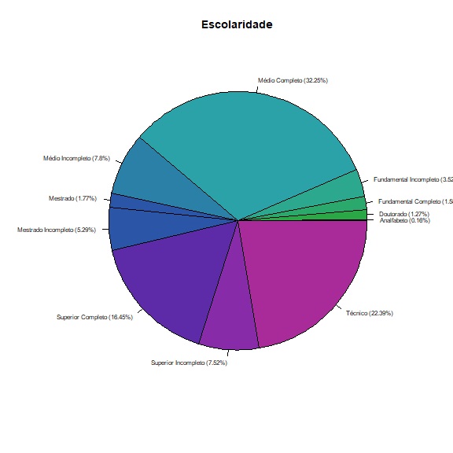

A partir desse gráfico vericamos que a maioria da população do noroeste fluminense possui um nível médio de escolaridade. Tendo prevalência de ensino médio completo (32,25%), seguido por técnico (22,39%) e superior completo (16,45%). É notável que os níveis mais altos e baixos de escolaridade possuem as menores porcentagens, como exemplo a taxa de doutorado é de 1,27% e a de analfabetismo, que é a menor parte da parcela da população, é de 0,16%.

Gráfico de Pizza - Ocupação

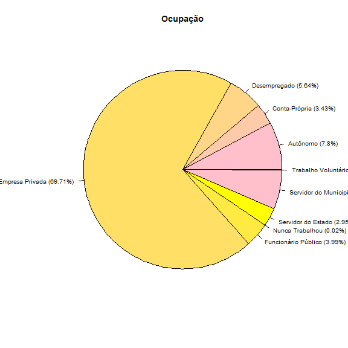

```r
> color <- colorRampPalette(c("pink","yellow"))
> contagem = table(PopulaçãoFluminense$Ocupação)
> nomes = levels(PopulaçãoFluminense$Ocupação)
> porcent = round(contagem/sum(contagem)*100,2)
> rotulo=paste(nomes," (",porcent,"%",")",sep="")
> pie(table(PopulaçãoFluminense$Ocupação),labels=rotulo, main="Ocupação",cex=0.8, col=color(7))
```

É possível observar que 69,71% dos entrevistados trabalham em empresas privadas e apenas 0,02% nunca trabalhou. É importante destacar que o trabalho em empresa privada se diversifica nos mais diversos setores, como por exemplo Consultor Sênior e Mecânico, as áreas de maior predomínio no noroeste fluminense.

Gráfico de Barras - Porcentagem de Escolaridade x Sexo

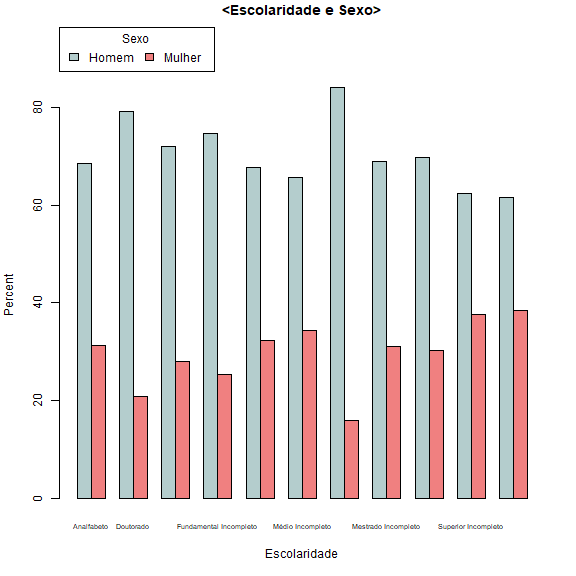

```r
> with(PopulaçãoFluminense, Barplot(Escolaridade, by=Sexo, style="parallel", legend.pos="above",
+   xlab="Escolaridade", ylab="Percent", main="<Escolaridade e Sexo>", scale="percent",col=c("lightcyan3","lightcoral"),cex.names=0.6))
```

Coluna de porcentagem:

```r
> local({
+   .Table <- xtabs(~Escolaridade+Sexo, data=PopulaçãoFluminense)
+   cat("\nFrequency table:\n")
+   print(.Table)
+   cat("\nRow percentages:\n")
+   print(rowPercents(.Table))
+   .Test <- chisq.test(.Table, correct=FALSE)
+   print(.Test)
+ })
```

```
Frequency table:
                        Sexo
Escolaridade             Homem Mulher
  Analfabeto                35     16
  Doutorado                327     86
  Fundamental Completo     370    144
  Fundamental Incompleto   857    290
  Médio Completo          7111   3390
  Médio Incompleto        1670    871
  Mestrado                 484     92
  Mestrado Incompleto     1187    536
  Superior Completo       3736   1619
  Superior Incompleto     1528    921
  Técnico                 4485   2806

Row percentages:
                        Sexo
Escolaridade             Homem Mulher Total Count
  Analfabeto              68.6   31.4   100    51
  Doutorado               79.2   20.8   100   413
  Fundamental Completo    72.0   28.0   100   514
  Fundamental Incompleto  74.7   25.3   100  1147
  Médio Completo          67.7   32.3   100 10501
  Médio Incompleto        65.7   34.3   100  2541
  Mestrado                84.0   16.0   100   576
  Mestrado Incompleto     68.9   31.1   100  1723
  Superior Completo       69.8   30.2   100  5355
  Superior Incompleto     62.4   37.6   100  2449
  Técnico                 61.5   38.5   100  7291

    Pearson's Chi-squared test

data:  .Table
X-squared = 287.91, df = 10, p-value < 2.2e-16
```

Para analisar esse gráfico foi levado em conta que a maioria dos entrevistados é homem (66,92%) e a minoria mulher (33,08%), o que reflete na escolaridade. Foi observado que a maior disparidade entre homens e mulheres está nos níveis escolares mais altos, sendo 79,2% dos que fazem doutorado homens e apenas 20,8% mulheres, e 84% dos que fazem mestrado são homens contra 16% que são mulheres. Esses percentuais não se justificam pela maioria homem, mas provavelmente por uma desigualdade de gênero, tendo menos mulheres chegando a níveis escolares altos.

Gráfico de Barras - Porcentagem de IMC x Sexo

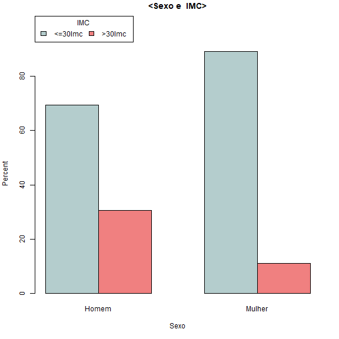

```r
> with(PopulaçãoFluminense, Barplot(Sexo, by=IMC, style="parallel", legend.pos="above", xlab="Sexo", ylab="Percent", main="<Sexo e  IMC>", scale="percent",
+   col=c("lightcyan3","lightcoral")))
```

Coluna de porcentagem:

```r
> local({
+   .Table <- xtabs(~Sexo+IMC, data=PopulaçãoFluminense)
+   cat("\nFrequency table:\n")
+   print(.Table)
+   cat("\nRow percentages:\n")
+   print(rowPercents(.Table))
+   .Test <- chisq.test(.Table, correct=FALSE)
+   print(.Test)
+ })
```

```
Frequency table:
        IMC
Sexo      <=30Imc  >30Imc
  Homem     15128    6662
  Mulher     9592    1179

Row percentages:
        IMC
Sexo      <=30Imc  >30Imc Total Count
  Homem      69.4    30.6   100 21790
  Mulher     89.1    10.9   100 10771

    Pearson's Chi-squared test

data:  .Table
X-squared = 1518.9, df = 1, p-value < 2.2e-16
```

O IMC é utilizado para avaliar o peso do indivíduo em relação a sua altura e, a partir disso, indicar se esse está dentro do peso ideal ou não. Um IMC acima de 30 categoriza obesidade. A partir do gráfico é possível constatar que o IMC abaixo de 30 é prevalente entre homens (69,4%) e mulheres (89,1%). Apesar disso, é alarmante a taxa de 30,6% dos homens estarem com o IMC acima de 30, contra apenas 10,9% das mulheres. É notável a diferença entre homens e mulheres com o IMC acima de 30, 30,6% e 10,9%, respectivamente.

Boxplot - Sexo x Horas de Trabalho na Semana

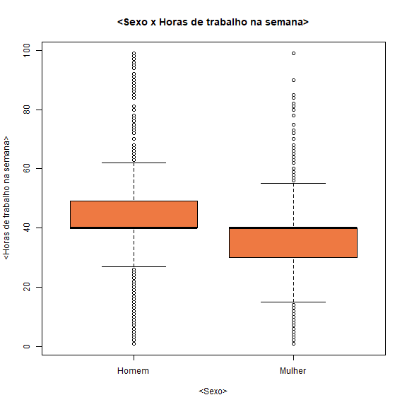

```r
> Boxplot(Horas.de.trabalho.na.semana~Sexo, data=PopulaçãoFluminense, id.method="none",
+   xlab="<Sexo>", ylab="<Horas de trabalho na semana>",
+   main="<Sexo x Horas de trabalho na semana>", col="sienna2")
```

```r
> numSummary(PopulaçãoFluminense[,"Horas.de.trabalho.na.semana", drop=FALSE],
+   groups=PopulaçãoFluminense$Sexo, statistics=c("mean", "sd", "IQR", "quantiles", "cv"),
+   quantiles=c(0,.25,.5,.75,1))
```

```
           mean       sd IQR        cv 0% 25% 50% 75% 100%
Homem  42.42809 12.11976   9 0.2856541  1  40  40  49   99
Mulher 36.41036 11.81130  10 0.3243939  1  30  40  40   99
       Horas.de.trabalho.na.semana:n
Homem                          21790
Mulher                         10771
```

Histograma - IMC x Horas de trabalho na Semana

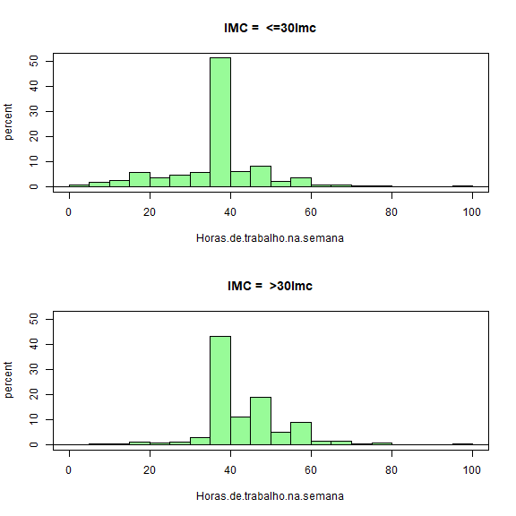

```r
> with(PopulaçãoFluminense, Hist(Horas.de.trabalho.na.semana, groups=IMC, scale="percent",
+   breaks="Sturges", col="palegreen"))
```

As cargas horárias maiores influênciam no estresse e tempo de planejamentoe/execução de refeições sendo esse um possível motivo para o IMC mais elevado nos homens, já que foi constatado que esses trabalham em média mais que as mulheres.

Gráfico de Barras - Divisão dos sexos por ocupação

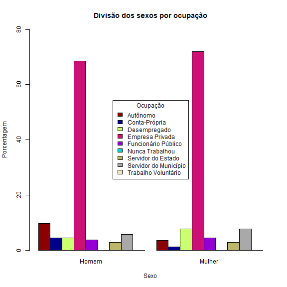

```r
> with(PopulaçãoFluminense, Barplot(Sexo, by=Ocupação, style="parallel", legend.pos="center",
+   xlab="Sexo", ylab="Porcentagem", main="Divisão dos sexos por ocupação", scale="percent",
+   col=c("darkred", "darkblue", "darkolivegreen1", "deeppink3", "darkviolet", "darkturquoise",
+   "darkkhaki", "darkgrey", "lemonchiffon2") ,ylim=c(0,80)))
```

```r
> library(abind, pos=17)
```

```r
> local({
+   .Table <- xtabs(~Sexo+Ocupação, data=PopulaçãoFluminense)
+   cat("\nFrequency table:\n")
+   print(.Table)
+   cat("\nColumn percentages:\n")
+   print(colPercents(.Table))
+   .Test <- chisq.test(.Table, correct=FALSE)
+   print(.Test)
+ })
```

```
Frequency table:
        Ocupação
Sexo     Autônomo Conta-Própria Desempregado Empresa Privada
  Homem      2142           981          996           14944
  Mulher      399           135          839            7752
        Ocupação
Sexo     Funcionário Público Nunca Trabalhou Servidor do Estado
  Homem                  809               5                645
  Mulher                 489               2                315
        Ocupação
Sexo     Servidor do Município Trabalho Voluntário
  Homem                   1258                   9
  Mulher                   835                   5

Column percentages:
        Ocupação
Sexo     Autônomo Conta-Própria Desempregado Empresa Privada
  Homem      84.3          87.9         54.3            65.8
  Mulher     15.7          12.1         45.7            34.2
  Total     100.0         100.0        100.0           100.0
  Count    2541.0        1116.0       1835.0         22696.0
        Ocupação
Sexo     Funcionário Público Nunca Trabalhou Servidor do Estado
  Homem                 62.3            71.4               67.2
  Mulher                37.7            28.6               32.8
  Total                100.0           100.0              100.0
  Count               1298.0             7.0              960.0
        Ocupação
Sexo     Servidor do Município Trabalho Voluntário
  Homem                   60.1                64.3
  Mulher                  39.9                35.7
  Total                  100.0               100.0
  Count                 2093.0                14.0
```

```
    Pearson's Chi-squared test

data:  .Table
X-squared = 769.35, df = 8, p-value < 2.2e-16
```

Esse gráfico de divisão dos sexos por ocupação mostra que a maior parte dos homens (14944) e das mulheres (7752) trabalham em empresas privadas. Pode-se perceber que uma classe que está bem equilibrada entre os sexos é a de desempregado, com um total de 1835 pessoas desempregadas. Desses desempregados, 996 são homens (54,3%) e 839 (45,7%). Levando também em conta que, dos estrevistados a maioria é homem e a minoria é mulher, essa diferença também reflete na divisão das ocupações. Justo por haver essa diferença devido ao maior número de homens entrevistados do que mulheres, os dados acabam por mostrar também uma maior diferença quanto a presença masculina nas ocupações em relação as mulheres.

Matriz de Correlação - Anos de estudo x Renda

```r
> cor(PopulaçãoFluminense[,c("Anos.de.estudo","Salário..em.12meses.")], use="complete")
```

```
                     Anos.de.estudo Salário..em.12meses.
Anos.de.estudo           1.00000000          -0.04319463
Salário..em.12meses.    -0.04319463           1.00000000
```

```r
> M<-cor(PopulaçãoFluminense[,c("Anos.de.estudo","Salário..em.12meses.")], use="complete")
```

```r
> M<-cor(PopulaçãoFluminense[,c("Anos.de.estudo","Salário..em.12meses.")], use="complete")
```

```r
> M
```

```
                     Anos.de.estudo Salário..em.12meses.
Anos.de.estudo           1.00000000          -0.04319463
Salário..em.12meses.    -0.04319463           1.00000000
```

```r
> require(corrplot)
```

````
```r
> corrplot(M,addCoef.col=TRUE,number.cex=0.7)
````

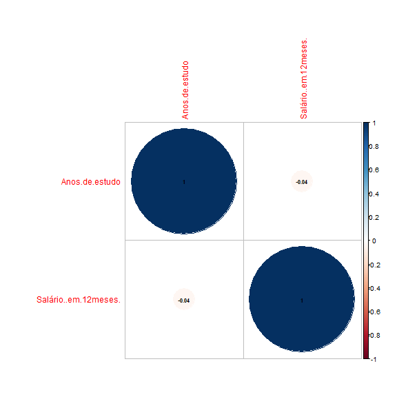

```r
> require(corrplot)
```

A correlação foi realizada pelo método de Pearson, também chamado de “Produto momento de Pearson”. O valor da correlação obtido foi de -0,04, um valor que não é considerado forte. Isso significa que os anos de estudo não influenciam na renda. Com esta analise podemos concluir que a relação de crescimento entre variáveis não é diretamente proporcional.

Diagrama de Dispersão - Anos de estudo x Renda

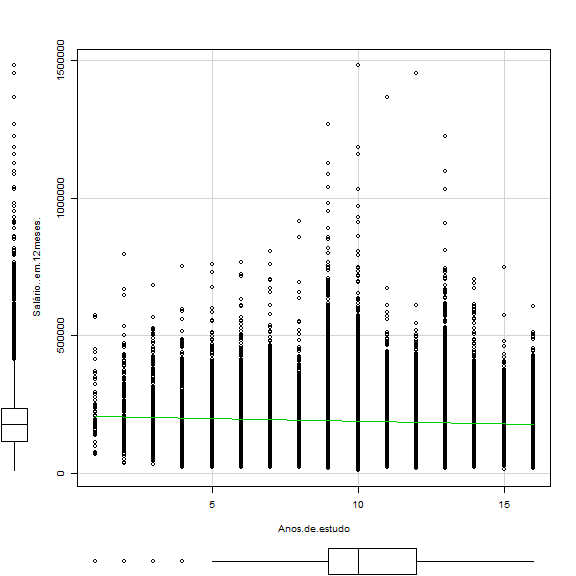

```r
> scatterplot(Salário..em.12meses.~Anos.de.estudo, reg.line=lm, smooth=FALSE, spread=TRUE,
+   boxplots='xy', span=0.5, ellipse=FALSE, levels=c(.5, .9), data=PopulaçãoFluminense)
```

A análise do diagrama de dispersão mostra que essas variáveis não possuem relação. Ou seja, uma não possui impacto na outra, os anos de estudo não influenciam na renda. A linha de quadrados minimos é uma reta decrescente

Histograma - IMC x Idade

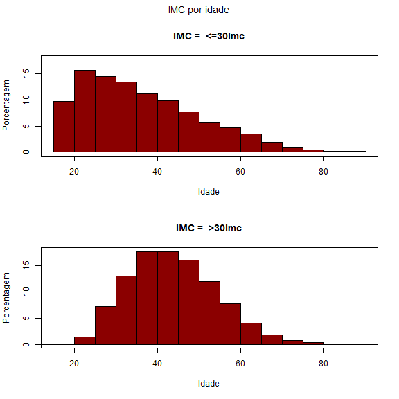

```r
> with(PopulaçãoFluminense, Hist(IDADE, groups=IMC, scale="percent", breaks="Sturges",
+   col="darkred", xlab="Idade", ylab="Porcentagem", main="IMC por idade"))
```

A análise desses histogramas revelam que a porcentagem dos indivíduos com IMC < 30 sobe a partir dos 20 anos de idade, porém, vai decaindo nitidamente com o passar dos anos. A porcentagem dos indivíduos com IMC > 30 sobe também a partir dos 20 anos, quando chega na faixa dos 35-45 anos se mantem mas, ao ultrapassar essa faixa, a porcentagem vai decrescendo nitidamente Conforme vão avançando com a idade, novas responsabilidades aparecem e fica mais difícil da pessoa manter um padrão de vida saudável e isso se reflete nesses resultados ilustrados pelo gráfico. No início cresce rapidamente, mas com o passar dos anos vai decrescendo. Poucas pessoas conseguem manter um padrão de vida saudável durante o decorrer de suas vidas.

Conclusão Através da análise de gráficos sobre os hábitos da população do Noroeste Fluminense é possível concluir que a qualidade da alimentação das pessoas está diretamente ligada a sua rotina de trabalho/estudo. As pessoas passam a maior parte do seu dia no local de trabalho, falta tempo para planejamento e preparo do alimento, logo, as opções ficam reduzidas a: preparo de comidas rápidas, frituras ou congelados e fazer as refeições em restaurantes e self-services. Essas práticas causam prejuízos não só a saúde do indivíduo como também ao seu desempenho profissional. Para o tratamento da obesidade o ideal é ter uma equipe interdisciplinar: médicos (várias especialidades como psiquiatra e endocrinologista), nutricionistas, psicólogos, educadores físicos, fisioterapeutas. Isto seria o ideal, mas precisamos começar com o que é possível campanhas de conscientização sobre hábitos alimentares e exercícios físicos devem ser recorrentes. O alto índice de IMC elevado é problema não só da população do Noroeste Fluminense, mas de todo o país. A interpretação dos gráficos nos permite também a percepção sobre o cenário educacional da região, onde o percentual da população com ensino superior fica em terceiro lugar, atrás dos ensinos médio e técnico. O problema da ocupação das vagas em ensinos superiores também é uma questão que o país, como um todo veio resolvendo ao longo dos anos, porém os dados acima demonstram que ainda há o que fazer, que o ensino médio ainda precisa ser reforçado para dar base ao ingresso dos estudantes às universidades. Diante dos dados analisados fica evidente que os hábitos interferem na saúde do indivíduo, porém o ambiente, sociedade em que vive e as condições sociais também fazem parte da construção do histórico das pessoas.

```r
> PopulaçãoFluminense <- readXL("C:/Users/perei/Desktop/adultos_do_Noroeste Fluminense.xlsx",
+   rownames=FALSE, header=TRUE, na="", sheet="banco", stringsAsFactors=TRUE)
```